# Linear Regression Assignment

Author

Aziz Al Mezraani, Mendoza College of Business

Published

November 3, 2024

# Set Up

```r
load("nba_data.rda") # Load data
```

The dataset we are using contains statistics on NBA games from 2010 to 2021, the features in the data are:

The statistics calculated are:

- fgm - Field goals made
- fga - Field goals attempted
- fg3m - 3 point shots made
- fg3a - 3 point shots attempted
- fg2m - 2 point shots made
- fg2a - 2 point shots attempted
- ftm - Free throws made
- fta - Free throws attempted
- oreb - Offensive rebounds
- dreb - Defensive rebounds
- treb - Total rebounds
- ast - Assists
- stl - Steals
- blk - Blocks
- tov - Turnovers
- pf - Personal fouls
- pts - Points scored
- pctfg - Field goal percentage
- pctfg2 - 2 point field goal percentage
- pctfg3 - 3 point field goal percentage
- pctft - Free throw percentage

These are calculated for the different aspects of the matchup denoted by the following adjustments to the variable names:

- _1_off - Offensive stats for team 1 in previous games
- _1_def - Defensive stats for team 1 in previous games (That is stats from team 1’s opponents)
- _2_off - Offensive stats for team 2 in previous games
- _2_def - Defensive stats for team 2 in previous games (That is stats from team 2’s opponents)

There is also an ELO rating function which can be used to provide a ranking of the teams:

https://medium.com/purple-theory/what-is-elo-rating-c4eb7a9061e0

The objective of our analysis is to determine the key factors involved in winning NBA games, so we will use point differential as our response variable.

```r
# Create response variable
nba_data$point_diff <- nba_data$team_1_points - nba_data$team_2_points
```

Before running the model we want to drop all of the unique identifiers for the games and the points used to calculate the differential:

```r
# Drop columns
nba_model <- nba_data[,c(8:91, 94:96)]
```

# Assignment

Please complete the following tasks and answer the following questions:

- 1 - Create two visualizations which may reveal interesting relationships in the dataset. Describe what you see in the visualization. (2 Points)

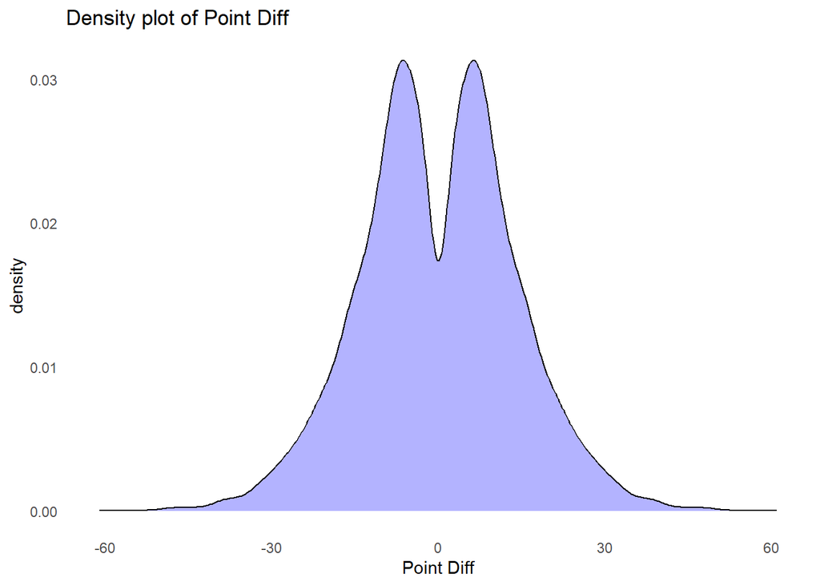

```r
library(ggplot2)
g_1 <- ggplot(nba_model, aes(x = point_diff)) +
  geom_density(fill = "blue", alpha = 0.3) +
  theme_minimal() +
  theme(panel.grid.major = element_blank(),
        panel.grid.minor = element_blank(),
        panel.border = element_blank(),
        panel.background = element_blank()) +
  labs(x = "Point Diff",
       title = "Density plot of Point Diff")
g_1
```

I see a mirrored density graph (this is due to the data having repeat games). However if we ignore the mirroring we realize most of the values are between 0 and 30 (with a peak between 1-10) and then the right tail (for the values greater than 0) extends all the way to 60. This hints at a right skewed distribution

Also it is important to note games cannot finish at 0 as it goes to over time this is due to the duplication of games

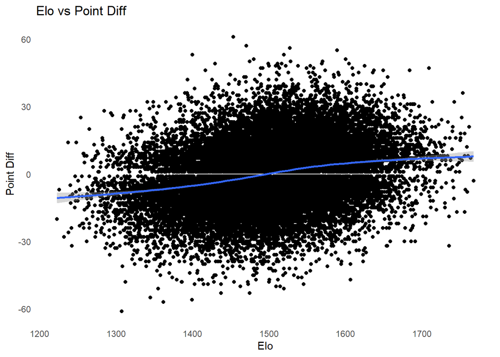

```r
g_2 <- ggplot(nba_model, aes(x = elo_1, y = point_diff )) +
  geom_point() +
  geom_smooth() +
  theme_minimal() +
  theme(panel.grid.major = element_blank(),
        panel.grid.minor = element_blank(),
        panel.border = element_blank(),
        panel.background = element_blank()) +
  labs(x = "Elo", y = "Point Diff",
       title = "Elo vs Point Diff")
g_2
```

Once again we see the some sort of mirror effect since point difference is involved but not symmetrical. We can see an extremely small hint of an increasing trend however it is very hard to see. The relationship does not seem significant as a lone predictor. This slightly hints at the idea that as the elo gets higher point diff increases (slight +ve).

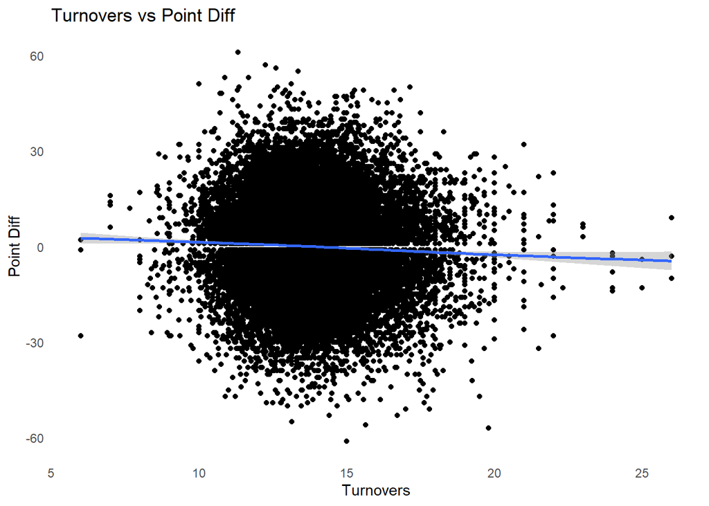

```r
g_3 <- ggplot(nba_model, aes(x = tov_1_off, y = point_diff )) +
  geom_point() +
  geom_smooth() +
  theme_minimal() +
  theme(panel.grid.major = element_blank(),
        panel.grid.minor = element_blank(),
        panel.border = element_blank(),
        panel.background = element_blank()) +
  labs(x = "Turnovers", y = "Point Diff",
       title = "Turnovers vs Point Diff")
g_3
```

Once again we see some sort of mirror effect since point difference is involved but not symmetrical. We can see an extremely small hint of a decreasing trend however it is very hard to see. The relationship does not seem significant as a lone predictor. This slightly hints at the idea that as turnover gets higher point diff decreases (slightly -ve).

- 2 - Run a linear regression model on the dataset using `point_diff` as the response variable and all other variables in the model data as explanatory variables. (1 Point)

```r
fit_1 <- lm(point_diff ~ .,
            data = nba_model)
summary (fit_1)
```

```
Call:
lm(formula = point_diff ~ ., data = nba_model)

Residuals:
    Min      1Q  Median      3Q     Max
-57.249  -8.270  -0.001   8.290  57.911

Coefficients: (16 not defined because of singularities)
               Estimate Std. Error t value Pr(>|t|)
(Intercept)  -1.683e+01  6.866e+01  -0.245 0.806317
fgm_1_off     1.347e+00  8.183e-01   1.646 0.099747 .
fga_1_off    -7.241e-01  3.838e-01  -1.887 0.059211 .
fg3m_1_off   -5.723e-01  4.469e-01  -1.281 0.200335
fg3a_1_off    4.471e-01  2.044e-01   2.187 0.028728 *
fg2m_1_off           NA         NA      NA       NA
fg2a_1_off           NA         NA      NA       NA
ftm_1_off     3.031e-02  4.742e-01   0.064 0.949034
fta_1_off    -1.374e-02  3.657e-01  -0.038 0.970027
oreb_1_off    2.764e-01  8.899e-02   3.106 0.001901 **
dreb_1_off    2.203e-01  6.430e-02   3.426 0.000614 ***
treb_1_off           NA         NA      NA       NA
ast_1_off     1.202e-01  4.380e-02   2.745 0.006058 **
stl_1_off     3.867e-01  9.299e-02   4.158 3.22e-05 ***
blk_1_off     1.854e-01  7.991e-02   2.320 0.020326 *
tov_1_off    -3.675e-01  8.572e-02  -4.287 1.82e-05 ***
pf_1_off      1.373e-01  6.597e-02   2.081 0.037457 *
pts_1_off            NA         NA      NA       NA
pctfg_1_off  -5.284e+01  6.495e+01  -0.814 0.415874
pctfg2_1_off -2.064e+01  2.217e+01  -0.931 0.351977
pctfg3_1_off  5.612e+00  7.233e+00   0.776 0.437773
pctft_1_off   7.841e+00  1.130e+01   0.694 0.487711
fgm_1_def    -2.781e+00  9.925e-01  -2.802 0.005079 **
fga_1_def     1.301e+00  4.659e-01   2.793 0.005230 **
fg3m_1_def    8.153e-01  6.714e-01   1.214 0.224605
fg3a_1_def   -4.456e-01  3.046e-01  -1.463 0.143534
fg2m_1_def           NA         NA      NA       NA
fg2a_1_def           NA         NA      NA       NA
ftm_1_def    -6.687e-01  6.736e-01  -0.993 0.320889
fta_1_def     3.766e-01  5.150e-01   0.731 0.464626
oreb_1_def   -3.269e-01  1.116e-01  -2.930 0.003391 **
```

[output cut: 48 more lines]

```
pf_2_def     -1.319e-01  9.395e-02  -1.404 0.160252
pts_2_def            NA         NA      NA       NA
pctfg_2_def  -1.361e+02  7.679e+01  -1.773 0.076249 .
pctfg2_2_def -3.649e+01  3.437e+01  -1.062 0.288339
pctfg3_2_def -1.045e+01  1.070e+01  -0.977 0.328546
pctft_2_def  -2.188e+01  1.611e+01  -1.359 0.174287
elo_2        -2.418e-02  1.713e-03 -14.117  < 2e-16 ***
elo_1         2.583e-02  1.649e-03  15.668  < 2e-16 ***
---
Signif. codes:  0 '***' 0.001 '**' 0.01 '*' 0.05 '.' 0.1 ' ' 1

Residual standard error: 12.77 on 27895 degrees of freedom
  (430 observations deleted due to missingness)
Multiple R-squared:  0.157, Adjusted R-squared:  0.1549
F-statistic: 74.21 on 70 and 27895 DF,  p-value: < 2.2e-16
```

- 3 - What features in the model were significant (At 0.1% level)? Do these variables have a positive or negative effect on a teams change of winning a game? (1 Point)
  - dreb_1_off (+ve)
  - stl_1_off (+ve)
  - tov_1_off (-ve)
  - ast_1_def (-ve)
  - ast_2_def (+ve)
  - elo_1 (+ve)
  - elo_2 (-ve)
- 4 - Visualize two potential interaction terms and their relationship with the response variable. Are these interaction terms likely to have a significant relationship with the response variable? (2 Points)

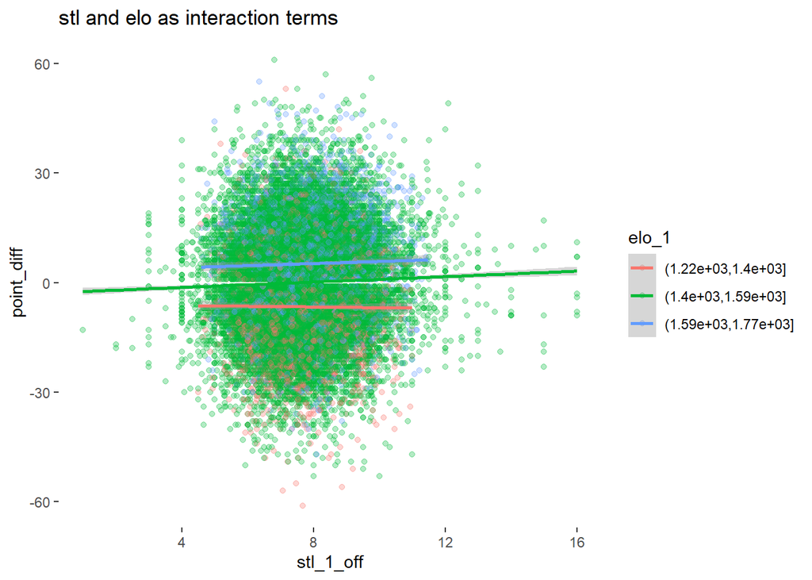

```r
g_4 <- ggplot(nba_model,
              aes(y = point_diff,
                  x = stl_1_off,
                  color = cut(elo_1, 3))) +
  geom_point(alpha = 0.3) +
  geom_smooth(method = "lm") +
  theme_bw() +
  theme(panel.grid.major = element_blank(),
        panel.grid.minor = element_blank(),
        panel.border = element_blank(),
        panel.background = element_blank()) +
  labs(y = "point_diff",
       x = "stl_1_off",
       color = "elo_1",
       title = "stl and elo as interaction terms")

g_4
```

Slopes are extremely similar for the middle and high values of elo, however the differs a bit for the low ones. They seems to usually lose which makes sense. This difference could also be due to smaller sample size. However the difference in slopes does not seem too strong so I do not think it will be an extremlhy strong interaction term.

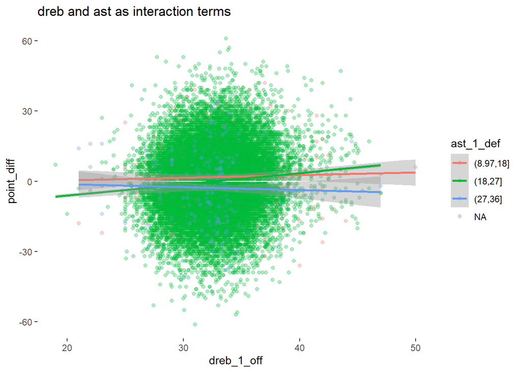

```r
g_5 <- ggplot(nba_model,
              aes(y = point_diff,
                  x = dreb_1_off,
                  color = cut(ast_1_def, 3))) +
  geom_point(alpha = 0.3) +
  geom_smooth(method = "lm") +
  theme_bw() +
  theme(panel.grid.major = element_blank(),
        panel.grid.minor = element_blank(),
        panel.border = element_blank(),
        panel.background = element_blank()) +
  labs(y = "point_diff",
       x = "dreb_1_off",
       color = "ast_1_def",
       title = "dreb and ast as interaction terms")

g_5
```

slopes seem different for all different levels of assists thus hinting at a potential significant interaction term.

- 5 - Fit a linear regression model with the two interaction terms included. (1 Point)

```r
fit_2 <- lm(point_diff ~ . + stl_1_off * elo_1 + dreb_1_off *ast_1_def ,
            data = nba_model)
summary (fit_2)
```

```
Call:
lm(formula = point_diff ~ . + stl_1_off * elo_1 + dreb_1_off *
    ast_1_def, data = nba_model)

Residuals:
    Min      1Q  Median      3Q     Max
-57.283  -8.273   0.004   8.293  57.669

Coefficients: (16 not defined because of singularities)
                       Estimate Std. Error t value Pr(>|t|)
(Intercept)          -1.492e+01  6.932e+01  -0.215 0.829602
fgm_1_off             1.358e+00  8.189e-01   1.658 0.097279 .
fga_1_off            -7.299e-01  3.841e-01  -1.900 0.057381 .
fg3m_1_off           -5.822e-01  4.471e-01  -1.302 0.192876
fg3a_1_off            4.521e-01  2.045e-01   2.210 0.027091 *
fg2m_1_off                   NA         NA      NA       NA
fg2a_1_off                   NA         NA      NA       NA
ftm_1_off             3.647e-02  4.743e-01   0.077 0.938710
fta_1_off            -1.851e-02  3.657e-01  -0.051 0.959643
oreb_1_off            2.788e-01  8.902e-02   3.132 0.001736 **
dreb_1_off            4.480e-01  3.002e-01   1.492 0.135641
treb_1_off                   NA         NA      NA       NA
ast_1_off             1.204e-01  4.394e-02   2.739 0.006162 **
stl_1_off            -6.153e-01  1.264e+00  -0.487 0.626296
blk_1_off             1.856e-01  7.995e-02   2.321 0.020281 *
tov_1_off            -3.657e-01  8.580e-02  -4.263 2.03e-05 ***
pf_1_off              1.387e-01  6.598e-02   2.101 0.035619 *
pts_1_off                    NA         NA      NA       NA
pctfg_1_off          -5.291e+01  6.506e+01  -0.813 0.416052
pctfg2_1_off         -2.115e+01  2.219e+01  -0.953 0.340463
pctfg3_1_off          5.567e+00  7.233e+00   0.770 0.441466
pctft_1_off           7.683e+00  1.130e+01   0.680 0.496534
fgm_1_def            -2.740e+00  9.960e-01  -2.751 0.005941 **
fga_1_def             1.280e+00  4.678e-01   2.737 0.006212 **
fg3m_1_def            8.258e-01  6.733e-01   1.227 0.220001
fg3a_1_def           -4.440e-01  3.062e-01  -1.450 0.147122
fg2m_1_def                   NA         NA      NA       NA
fg2a_1_def                   NA         NA      NA       NA
ftm_1_def            -6.310e-01  6.748e-01  -0.935 0.349761
fta_1_def             3.472e-01  5.159e-01   0.673 0.500972
```

[output cut: 51 more lines]

```
pctfg_2_def          -1.374e+02  7.680e+01  -1.789 0.073705 .
pctfg2_2_def         -3.564e+01  3.438e+01  -1.037 0.299801
pctfg3_2_def         -1.040e+01  1.070e+01  -0.972 0.330850
pctft_2_def          -2.199e+01  1.611e+01  -1.365 0.172284
elo_2                -2.420e-02  1.713e-03 -14.128  < 2e-16 ***
elo_1                 2.087e-02  6.585e-03   3.169 0.001529 **
stl_1_off:elo_1       6.656e-04  8.375e-04   0.795 0.426780
dreb_1_off:ast_1_def -1.009e-02  1.303e-02  -0.774 0.438925
---
Signif. codes:  0 '***' 0.001 '**' 0.01 '*' 0.05 '.' 0.1 ' ' 1

Residual standard error: 12.77 on 27893 degrees of freedom
  (430 observations deleted due to missingness)
Multiple R-squared:  0.157, Adjusted R-squared:  0.1549
F-statistic: 72.17 on 72 and 27893 DF,  p-value: < 2.2e-16
```

- 6 - How has the inclusion of the interaction terms affected the coefficients in the model? How has the inclusion of interaction terms affected the model fit? (1 Point)

The addition of the interaction terms took significance from elo_1, ast_1_def, stl_1_off, and dreb_1_off (all the terms included in the creation of the interaction terms.) making it no longer significant at the 0.1% level. This left only tov_1_off, ast_2_def and elo_2 as significant predictors at the 0.1% level. It is also important to note tht the interaction terms them selves are not significant.

Moreover, the addition of the terms caused stl_1_off sign to flipped to -ve and ast_1_def sign to flip to +ve.

As for values, there were slight changes but as for the significant predictors the changes were not extreme.

Lastly, the R-squared did not change after said additions thus no effect on the fit, they just made the model more complex (might be better to leave them out)

2 Points for code quality and analysis decisions.